# MA331-Report: 2212064

TED Talks by Speaker Chris Kluwe and Speaker Louie Schwartzberg

Kithalamane Basavaraj, Rahul

## Introduction

The aim of this project report is to present and compare text analysis for the transcripts given by **TWO TED speakers**.

**Speaker 1**: Chris Kluwe  
**Speaker 2**: Louie Schwartzberg

Speaker 1: **Chris Kluwe** is a punter and an author who consistently sets team records. In 2014, he gave a TED Talk on How augmented reality will change sports and build empathy. In his talk he describes how the future of sports will look like with respect to technology and how in future the use of augmented reality will enhance people’s experience with respect to sports. He gives a sense of what virtual reality and augmented reality (AR) is, explains how AR can collect data in real time and be used to enhance when we play the game.

Speaker 2: **Louie Schwartzberg** is a Filmmaker who has captured breath taking images of the universes rhythms, patterns and beauty. The speaker has given two TED Talks one in 2011 and the other in 2014. In 2011, he gave a TED Talk on The hidden beauty of pollination. He describes and films how essential the pollen and pollination is with respect to mother nature, reminds us that we dependent on them and all should work towards taking care of it. In 2014, he gave another TED Talk on the Hidden miracles of the natural world. In this he describes how technology, art and science can be brought together to make the invisible visible, which in turn expands and transforms our perception in the world we live.

The report aims to investigate:

1. Sentiment Analysis of two speakers.
2. Summaries and Word Counts for two speakers.
3. Comparisons between two speakers.

## Methods

The steps/procedures followed in this report are as follows:

1. Loading of data from dsEssex package.
2. Data pre-processing by breaking apart text into individual tokens and arranging the data into a specific structure.
3. Data Cleaning by removing all stopwords that are NOT interesting for a text analysis.
4. Conducting statistical Analysis for both the speakers by doing word count, vocabularary comparison by persons, calculating odds ratio to measure the association between two words.
5. Analysis of data are presented in a visualization format using ggplot package.
6. Detailed analysis of the results.

## Results

**1.** Here we made a detailed analysis on the **summary of word count** for each individual speakers with respect to their TED Talk and our analysis shows that speaker 1: **Chris Kluwe** has the maximum number of words i.e, 1578. It also indicates that the talk given by him has been covered in broad range. We also found that Speaker 2: **Louie Schwartzberg** has given 2 TED Talks one in 2011 and 2014 and the TED talk he gave in 2014 (talk_id = 1969) has the maximum number of words i.e, 797 compared to 2011. Given below is the Visualization of total words for certain speakers:

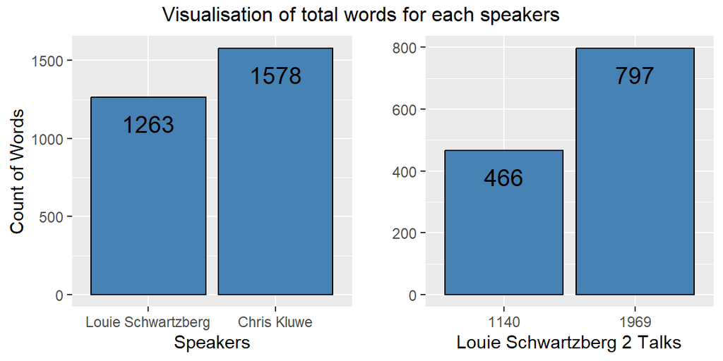

**2.** In this analysis we found the **words used maximum number of times** after removal of stop words, by Speaker 1: Chris Kluwe and Speaker 2: Louie Schwartzberg for the maximum number of times in their TED Talk. We made the analysis and found that the word - **can** is used the maximum number of times by both speaker word counts combined. In overall, the TED Talks given by both speakers suggests a positive attitude towards the topic. Given below is the Visualization of top words for both speakers.

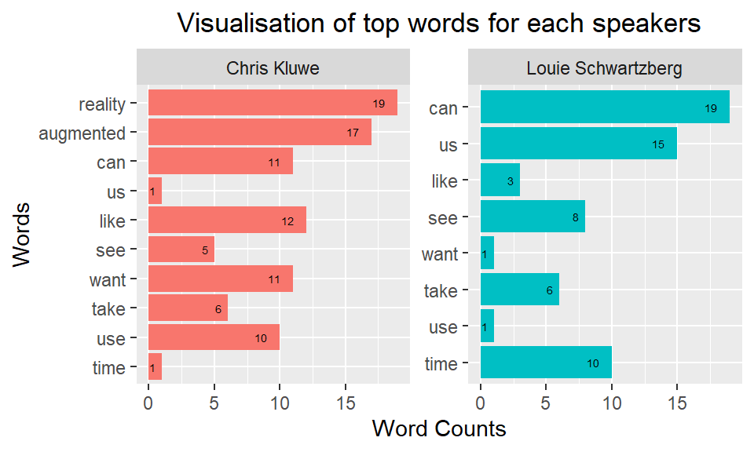

**3.** In this analysis we have **compared** speaker words, found similarities and differences in them. We identified that the common areas of overlapping in their talks were in the positive note. We also identified certain cloud of words in each of their talks, this indicated that these words were frequently occurring and findings show that the TED talk given by the speakers covered around them only. Given below is the graph of comparing speaker words using visualization:

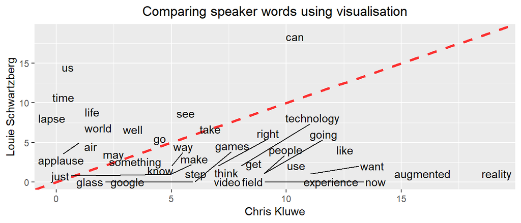

**4.** In this analysis we identified the emotional tone through the **percentage** of positive and negative words in their TED Talks. Speaker 2: **Louie Schwartzberg** has got higher percentage of positive words i.e, 63.04% which is indicating how optimistic he is if people start to care for mother nature. But when compared to Speaker 2, Speaker 1: **Chris Kluwe** has got 55% of positive words, which is only 5% more than the half way mark, this concludes that his Talk was neither too optimistic nor too pessimistic about how the future of sports will look like with respect to technology. But he indicates a sense of positivity its going to happen in near future. Given below is the graph of Percentage Sentiment Analysis:

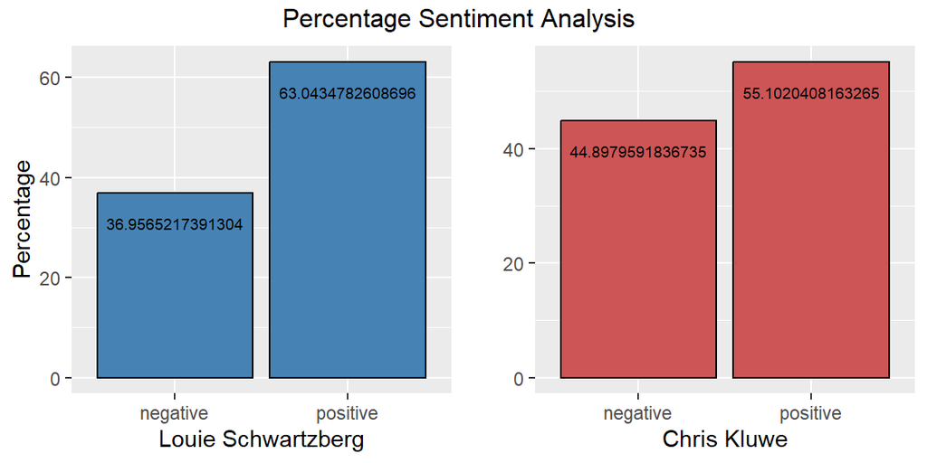

**5.** In our analysis here we present the graphical representation of **odds ratio summary** statistic.Positive OR ratio indicates sentiments are expressed towards Speaker 1: **Chris kluwe** and negative OR indicates sentiments are expressed towards Speaker 2: **Louie Schwartzberg**. The sentiments expressed by audiences are shown in the table. We observe mostly both the speakers “Chris Kluwe” and “Louie Schwartzberg” have received positive sentiments from the audiences

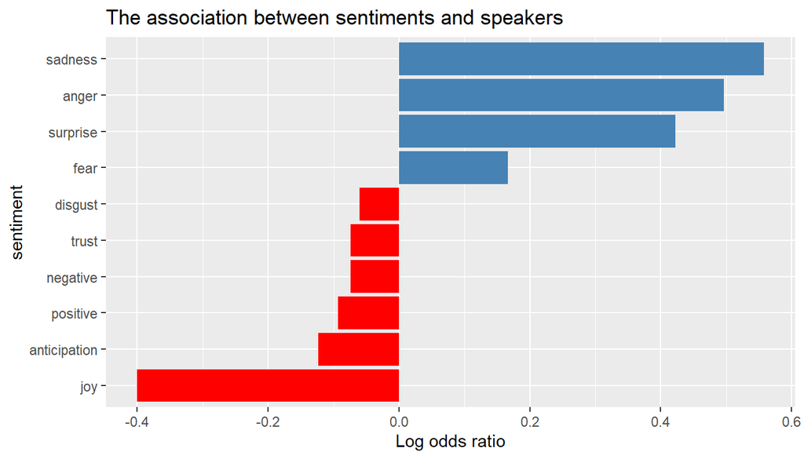

```
# A tibble: 10 × 5
   sentiment    `Chris Kluwe` `Louie Schwartzberg`    OR  log_OR
   <fct>                <int>                <int> <dbl>   <dbl>
 1 positive                67                   61 0.911 -0.0933
 2 anticipation            36                   34 0.884 -0.124
 3 negative                32                   29 0.929 -0.0742
 4 trust                   32                   29 0.929 -0.0742
 5 joy                     23                   28 0.670 -0.400
 6 fear                    22                   16 1.18   0.167
 7 surprise                21                   12 1.53   0.422
 8 sadness                 18                    9 1.75   0.557
 9 anger                   17                    9 1.64   0.496
10 disgust                 10                    9 0.941 -0.0607
```

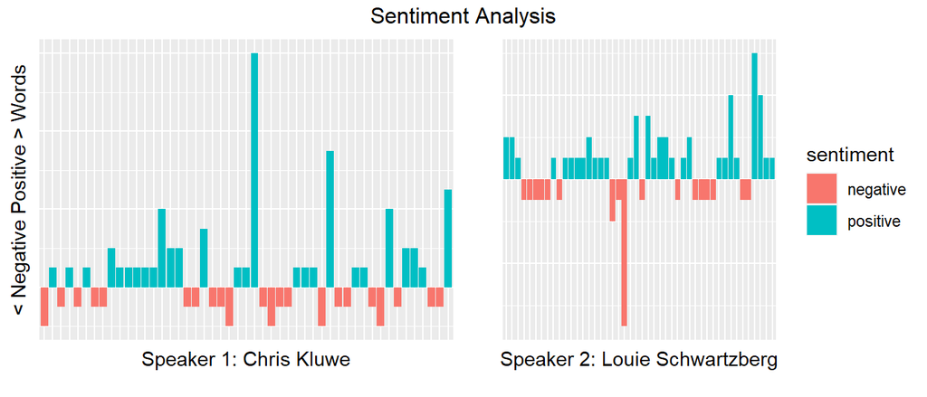